# Assignment - STATS 787: S1-26

Adam Wong-Toi - 362229162 (awon499)

2026-06-02

*For the sake of simplicity, code is automatically hidden for each visualisation, but is accessible by clicking the* `Show` *button on the right hand side above each plot*

Additionally, there are some sections that allow you to expand the text to show earlier iterations of plots, that are hidden by default for cleanliness, but still included to provide context to why I made design choices on certain plots. These look like this:

**Click to show…**

Success! You have opened an expansion section - keep an eye out for these throughout the report :)

### Data Loading

**Click to show**

```r
# All Files in Working Directory (14 files)
files <- list.files(pattern = "Streaming_History_Audio_.*\\.json")

data <- files |>
  map_df(~fromJSON(.x))

glimpse(data)
```

```
## Rows: 277,293
## Columns: 23
## $ ts                                <chr> "2015-11-12T20:43:29Z", "2015-11-12T…
## $ platform                          <chr> "Android OS 4.4.4 API 19 (samsung, S…
## $ ms_played                         <int> 0, 186443, 242440, 206066, 133665, 1…
## $ conn_country                      <chr> "NZ", "NZ", "NZ", "NZ", "NZ", "NZ", …
## $ ip_addr                           <chr> "122.62.7.225", "122.62.7.225", "122…
## $ master_metadata_track_name        <chr> "Title", "That's How You Know (feat.…
## $ master_metadata_album_artist_name <chr> "Meghan Trainor", "Nico & Vinz", "Ru…
## $ master_metadata_album_album_name  <chr> "Title", "That's How You Know (feat.…
## $ spotify_track_uri                 <chr> "spotify:track:0k5hoseEJnCAbpRh38dNo…
## $ episode_name                      <chr> NA, NA, NA, NA, NA, NA, NA, NA, NA, …
## $ episode_show_name                 <chr> NA, NA, NA, NA, NA, NA, NA, NA, NA, …
## $ spotify_episode_uri               <chr> NA, NA, NA, NA, NA, NA, NA, NA, NA, …
## $ audiobook_title                   <chr> NA, NA, NA, NA, NA, NA, NA, NA, NA, …
## $ audiobook_uri                     <chr> NA, NA, NA, NA, NA, NA, NA, NA, NA, …
## $ audiobook_chapter_uri             <chr> NA, NA, NA, NA, NA, NA, NA, NA, NA, …
## $ audiobook_chapter_title           <chr> NA, NA, NA, NA, NA, NA, NA, NA, NA, …
## $ reason_start                      <chr> "appload", "clickrow", "trackdone", …
## $ reason_end                        <chr> "endplay", "trackdone", "trackdone",…
## $ shuffle                           <lgl> FALSE, FALSE, FALSE, FALSE, FALSE, F…
## $ skipped                           <lgl> TRUE, FALSE, FALSE, FALSE, TRUE, FAL…
## $ offline                           <lgl> FALSE, FALSE, FALSE, FALSE, FALSE, F…
## $ offline_timestamp                 <dbl> NA, NA, NA, NA, NA, NA, NA, NA, NA, …
## $ incognito_mode                    <lgl> FALSE, FALSE, FALSE, FALSE, FALSE, F…
```

### Data Manipulation

**Click to show**

```r
streaming_data <- data |>
  mutate(time = ymd_hms(ts) |> with_tz(tzone = "Pacific/Auckland"), # ensure time zone, so time/hour related plots don't distort
         date = as.Date(time),
         hour = hour(time),
         month = month(time, label = TRUE),
         year = year(time),
         weekday = wday(time, label = TRUE)) |>
  drop_na(time)

names(streaming_data)
```

```
##  [1] "ts"                                "platform"
##  [3] "ms_played"                         "conn_country"
##  [5] "ip_addr"                           "master_metadata_track_name"
##  [7] "master_metadata_album_artist_name" "master_metadata_album_album_name"
##  [9] "spotify_track_uri"                 "episode_name"
## [11] "episode_show_name"                 "spotify_episode_uri"
## [13] "audiobook_title"                   "audiobook_uri"
## [15] "audiobook_chapter_uri"             "audiobook_chapter_title"
## [17] "reason_start"                      "reason_end"
## [19] "shuffle"                           "skipped"
## [21] "offline"                           "offline_timestamp"
## [23] "incognito_mode"                    "time"
## [25] "date"                              "hour"
## [27] "month"                             "year"
## [29] "weekday"
```

## Summary of the data

The data that I have selected for my STATS 787 Assignment is my own personal Spotify listening data. As a user of the streaming platform since early 2015, I have a large library of data that is available. Through Spotify, I have previously requested my extended music listening history, and imported this to a third party app that summarises my top artists, songs and total listening hours (like a more extended version of Spotify Wrapped, but available whenever I want. However, this is just the tip of the iceberg with what is available with this data. The information that this third party app, is very numbers based, with minimal interesting visualisations.

Being able to take the extended history JSON files and manipulating this into data frames in `R`, allows for a fascinating data discovery through a series of visualisations.

The data files from Spotify have a wide range of information stored as shown above, including basic song information like

- Artist
- Song title
- Timestamps of play
- Duration of play

But also more in depth information like

- Shuffle status
- Why the song started/ended
- Online/offline playback information
- Country played from
- Device played on.

Therefore, I believe that there is a significant depth of information that can be turned into some data visualisations.

### Questions of Interest

Despite there being many possible combinations of plots and visualisations, I have narrowed down my questions of interest to the following

1. What are the top artists listened to over time, and how do these change?
2. How do listening trends change over time, both on a monthly basis, but also on a weekly basis?
3. Where are my peak listening times?
4. If listening trends change over time, how does this vary?
5. Are there patterns with artists songs - for example, do some artists get skipped more than others?

Through the following visualisations, I aim to answer these questions, as well as link these to key data visualisation themes and concepts. However, some visualisations have limitations and are not as effective, these will also be discussed within the scope of the this analysis for each plot.

# Data Visualisations

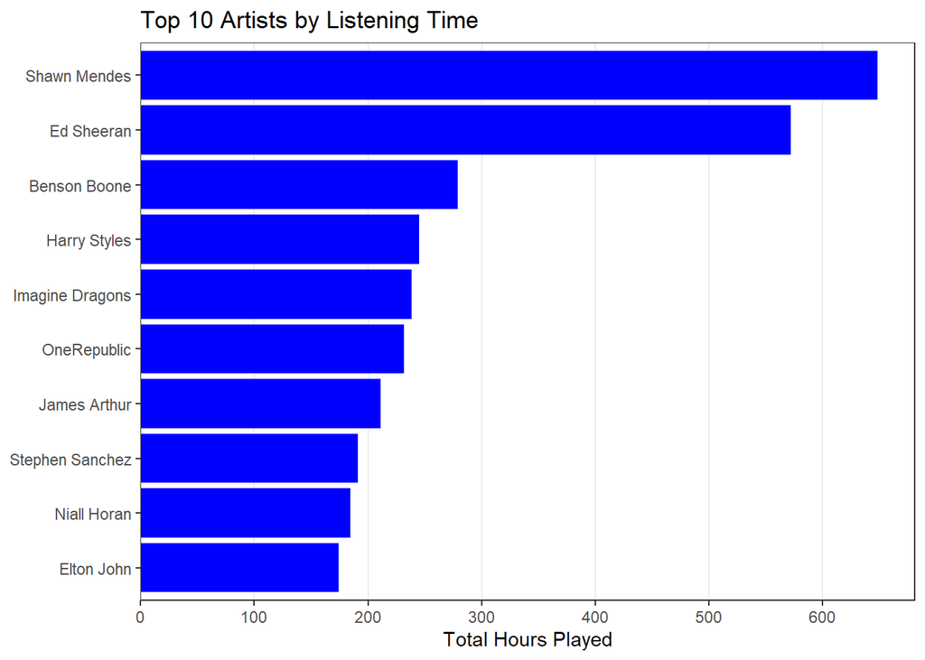

```r
streaming_data |>
  group_by(master_metadata_album_artist_name) |>
  summarise(total_hours = sum(ms_played) / 3600000) |>
  slice_max(total_hours, n = 10) |>
  ggplot(aes(x = total_hours, y = reorder(master_metadata_album_artist_name, total_hours), )) +
  geom_col(fill = "blue") +
  scale_x_continuous(breaks = seq(0, 600, 100), expand = expansion(c(0,0.05))) +
  labs(title = "Top 10 Artists by Listening Time",
       x = "Total Hours Played",
       y = NULL,) +
  theme_bw() +
  theme(panel.grid.major.y = element_blank(),
        panel.grid.minor.x = element_blank())
```

As a warm up, to answer the fairly simple first question of interest, I have a bar plot of the top 10 artists of all time, based on total listening hours. Total hours played is encoded as length of the bar, and artist is encoded as vertical position.

A key concept that I have learnt from data visualisations, is that sometimes, simpler is better. One of the most effective way to encode a categorical variable (in this case, artist), is with position. Qualitative data values are encoded to a qualitative visual feature, not introducing additionally information (like if an alternative encoding like area or angle was used).

The artist variable in this visualisation is an ordinal categorical variable, with the top artist at the top of the plot, and the 10th highest artist at the bottom. By ordering the artists by total hours played, instead of the default alphabetical order, allows us to more accurately compare the differences between artists with similar listening hours. Furthermore, they all have the same relative position to gain the most accurate decoding, with only vertical grid lines included to further improve the decoding of the total hours played data variable.

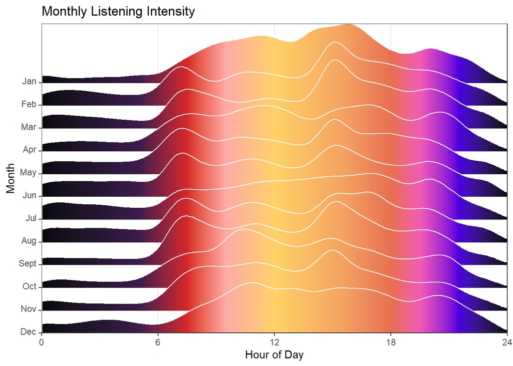

```r
colour_loop <- c(
  "#080810", # 00:00 Pitch Black / Midnight
  "#3A1C4D", # 05:00 Dark Morning
  "#D62828", # 07:30 Sunrise Red
  "#FFAAA6", # 09:30 Soft Morning Pink/Yellow
  "#FFD166", # 12:00 Bright Day Yellow
  "#F4A261", # 15:30 Afternoon Warm Orange
  "#E76F51", # 18:00 Late Sun Orange
  "#F15BB5", # 19:30 Vivid Pink Sunset
  "#4A00E0", # 21:30 Twilight Purple
  "#080810"  # 24:00 Loop back to Pitch Black
)

colour_loop_num <- c(0, 5, 7.5, 9.5, 12, 15.5, 18, 19.5, 21.5, 24) / 24

streaming_data |>
  ggplot(aes(x = hour, y = fct_rev(month), fill = after_stat(x))) +
  # Ridges
  geom_density_ridges_gradient(scale = 3,
                               rel_min_height = 0.01,
                               colour = "White",
                               linewidth = 0.5) +
  # Manual Colour override to colour loop cycle
  scale_fill_gradientn(colors = colour_loop,   #use _gradientn for vector of n-colours
                      values = colour_loop_num,
                      limits = c(0, 24)) +

  scale_x_continuous(breaks = c(0, 6, 12, 18, 24),
                     limits = c(0, 24),
                     expand = c(0, 0)) +

  scale_y_discrete(expand = expansion(c(0,0))) +

  labs(title = "Monthly Listening Intensity",
       x = "Hour of Day",
       y = "Month") +
  theme_bw() +
  theme(
    legend.position = "none",
    panel.grid.minor.x = element_blank(),
    axis.text.y = element_text(vjust = 0.2) #align text better
    )
```

In this visualisation time (hour of the day) is encoded as horizontal position, month as vertical position (reversed to make chronological sense) and music listening history as the ridge plots. This makes a visual shape from the densisty of the data per month, which is a data summary. I have utilised a key data visualisation concept here with colour. I have aimed to make a congruent encoding of colour by mapping different times of day, to different colours that are typically associated with that time. Although this is obviously very dependent on weather, the darker time overnight, with bright red sunrises, yellow/orange midday sunlight, and ending the day with a pink/purple to blue sunset into twilight.

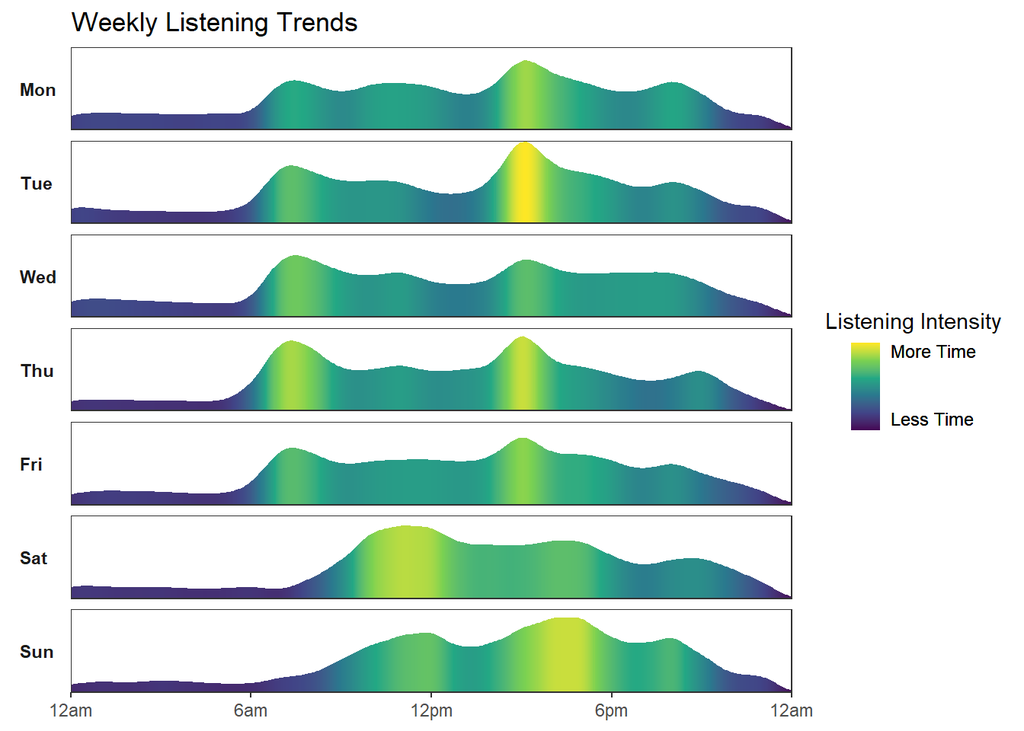

```r
weekday_totals <- streaming_data |>
  group_by(weekday) |>
  summarise(total_hours = sum(ms_played) / 3600000)

# Calculate objective listening totals per weekday
streaming_data_ordered <- streaming_data |>
  left_join(weekday_totals, by = "weekday") |>
  mutate(weekday = fct_relevel(weekday, "Mon", "Tue", "Wed", "Thu", "Fri", "Sat", "Sun"))

# Join back and plot
streaming_data_ordered |>
  ggplot(aes(x = hour, y = 0)) +

  # Fill with each days intensity
  geom_density_ridges_gradient(aes(fill = after_stat(density)),
                     colour = "white",
                     linewidth = 0.5,
                     alpha = 1) +

  scale_x_continuous(breaks = c(0, 6, 12, 18, 24),
                     labels = c("12am", "6am", "12pm", "6pm", "12am"),
                     limits = c(0, 24),
                     expand = expansion(c(0, 0))) +
  scale_y_continuous(expand = expansion(c(0, 0))) +

  # Custom Legend
  scale_fill_viridis_c(
    name = "Listening Intensity",
    option = "D",
    # Legend Range
    breaks = c(0.005, 0.095),
    # Map custom text strings directly to those positions
    labels = c("Less Time", "More Time"),
    # Shape the legend bar to look like a clean horizontal slider
    guide = guide_colourbar(
      barwidth = 1,
      barheight = 3,
      title.position = "top",
      title.hjust = 0.5,
      ticks = FALSE # Turn off the little interior tick lines
    )
  ) +

  # Facet stack
  facet_grid(weekday ~ ., switch = "y") +

  labs(
    title = "Weekly Listening Trends",
    x = NULL,
    y = NULL
  ) +
  theme_bw() +
  theme(
    # Facet Labels Tidy up
    strip.text.y.left = element_text(angle = 0, face = "bold", hjust = 0),
    strip.placement = "outside",
    strip.background = element_blank(),
    # Legend Tidy Up
    legend.ticks = element_blank(),
    legend.text = element_text(vjust = c(0, 1), size = 9, face = "plain"),
    # General Tidy Up
    panel.grid.minor.x = element_blank(),
    axis.text.y = element_blank(),
    axis.ticks.y = element_blank(),
    panel.grid = element_blank()
  )
```

To build off the limitations of the previous plot, I aim to improve this, by looking at a slightly different set of data values, but with the same ideas. A ridge plot/density plot is produced for each day of the week, but to account for the over plotting, these are split into facets. This keeps the same comparison position of time throughout the day (left to right), but now has each day in a different plot window. This allows us to better see the differences in the days profiles. This helps to understand and answer questions 2, 3 and 4, all relating to how trends change over time, peak times, and how these trends vary.

Instead of using a congruent encoding of colour to the time of day, I have instead coloured by the intensity of the listening (i.e. listening hours). This serves two purposes, highlighting peak times, but also allowing an easier comparison across different days. As we now no longer have the same reference position in each plot (due to the vertical stacking), it can be harder to distinguish subtle differences between the same time of different days, as the visual system needs to constantly move up and down plots, to try remember subtle differences in height. Now, it is easier to see the differences, as they are also encoded as colour. Using a contrasting viridis colour scale, with a bright yellow used for higher listening, we are instantly drawn towards these brighter colours as the stand outs for each day.

We can utilise the encoding of colour to help mitigate one of the downfalls of facets - no longer having the same relative positioning to compare. I trailed this visualisation by faceting into one row, instead of one column, but this condensed the day profile too much and was not as visually appealing as the above. Although not as well defined in terms of colour (like the monthly ridge plot), using this specific viridis still allows us to have darker colours for the overnight period, as well as maintaining a visually striking peak, is an added benefit of this visualisation.

Although it is not possible to decode exact data values from this plot, and the legend is a colour scale, which can be less accurate at decoding, this visualisation solves some of the issues from the previous ridge plot. We are able to accurately decode that for weekdays, there are peaks in the morning and evening, which roughly align with a typical working day. There are sometimes later night peaks, or continued higher streaming until about 10/11pm. On weekends, the peaks are later in the morning, and usually longer than weekdays, additionally, it can be seen that Sundays tend to be high music streaming days, with the largest peaks in the late afternoon.

Finally, with some minor changes to the legend and axis labels, we utilise the encoding of text, to make this visualisation even more easy to understand, making axis labels clearer, and legend labels informative to the colour scale encoding.

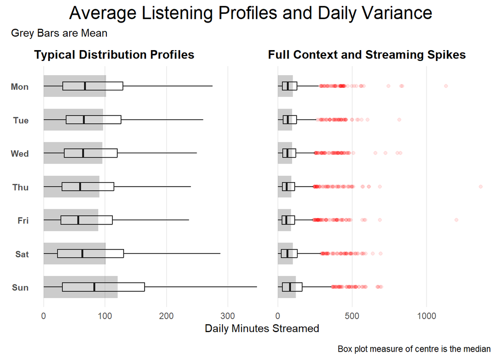

```r
daily_summary <- streaming_data |>
  group_by(date, weekday) |>
  summarise(daily_minutes = sum(ms_played) / 60000, .groups = "drop") |>
  filter(daily_minutes <= 1440) |>  # removes erroneous days that have more than 1 days worth of minutes
  mutate(
    weekday = factor(
      weekday,
      levels = c("Mon", "Tue", "Wed", "Thu", "Fri", "Sat", "Sun"),
      ordered = TRUE
    )
  )

# Plot 1: The Left Window - No outliers
p_left <- daily_summary |>
  ggplot(aes(x = daily_minutes, y = fct_rev(weekday))) +
  # Baseline average bar
  stat_summary(fun = mean, geom = "col", fill = "black", width = 0.65, alpha = 0.2, orientation = "y") +
  # Boxplot with hidden outlier points
  geom_boxplot(width = 0.25, colour = "grey10", alpha = 0.2, fill = "white",
               outlier.shape = NA) + # Hides the outlier dots
  # Dynamically zooms the window to cut off extreme values without altering statistical metrics
  coord_cartesian(xlim = c(0, quantile(daily_summary$daily_minutes, 0.95, na.rm = TRUE))) +
  labs(
    title = "Typical Distribution Profiles",
    x = "Daily Minutes Streamed",
    y = NULL
  ) +
  theme_minimal() +
  theme(
    plot.title = element_text(size = 12, face = "bold"),
    plot.subtitle = element_text(colour = "gray40", size = 9),
    panel.grid.minor = element_blank(),
    panel.grid.major.y = element_blank(),
    axis.text.y = element_text(face = "bold")
  )

# Plot 2: The Right Window with outliers
p_right <- daily_summary |>
  ggplot(aes(x = daily_minutes, y = fct_rev(weekday))) +
  stat_summary(fun = mean, geom = "col", fill = "black", width = 0.65, alpha = 0.2, orientation = "y") +
  geom_boxplot(width = 0.25, colour = "grey10", outlier.colour = "red",
               outlier.size = 1.5, alpha = 0.1, fill = "white") +
  labs(
    title = "Full Context and Streaming Spikes",
    x = "Daily Minutes Streamed",
    y = NULL
  ) +
  theme_minimal() +
  theme(
    plot.title = element_text(size = 12, face = "bold"),
    plot.subtitle = element_text(colour = "gray40", size = 9),
    panel.grid.minor = element_blank(),
    panel.grid.major.y = element_blank(),
    # Hide y-axis labels on the right plot since they share rows with the left plot
    axis.text.y = element_blank()
  )

# Combine Both Windows Side-by-Side
p_left + p_right +
  plot_layout(axes = "collect") +
  plot_annotation(
    title = "Average Listening Profiles and Daily Variance",
    subtitle = "Grey Bars are Mean",
    caption = "Box plot measure of centre is the median",
    theme = theme(plot.title = element_text(size = 18, hjust = 0.5))
  )
```

I now shift away from the ridge/density plots to see how the variation in data listening occurs, with slightly more numerical accuracy, through box plots and bar plots. By combining two similar plots, with the `patchwork` package, we can establish a coherent encoding composition of structure. This is valuable to answer the fourth question of interest, how trends vary over time.

The ideas of data summaries are explored in this plot. Whilst it is not possible to get an idea of the overall distribution of the days data (more so seen in the previous ridge plot), it is now possible to decode actual data values for certain summary statistics for each day, which is an improvement over the previous plots. The features of lower and upper quartile, as well as median and overall skew are encoded by the box plot visual shape. At a sacrifice of this, is missing ideas of multi-modality. There is an implicit assumption from a box plot that the data is uni modal at some measure of centre, however, multi-modality is lost in a box-plot. In my data, this is a feature that is lost, as every day has at least two peaks, as seen with the ridge plot.

Of note, it is likely that two outliers on Thursday and Friday, close to the maximum minutes per day (1440 minutes), would be from when I streamed a song on repeat for a day with my phone volume off, to help boost a small artists stream numbers on a new release.

**Click to show Iteration 1 of the next plot**

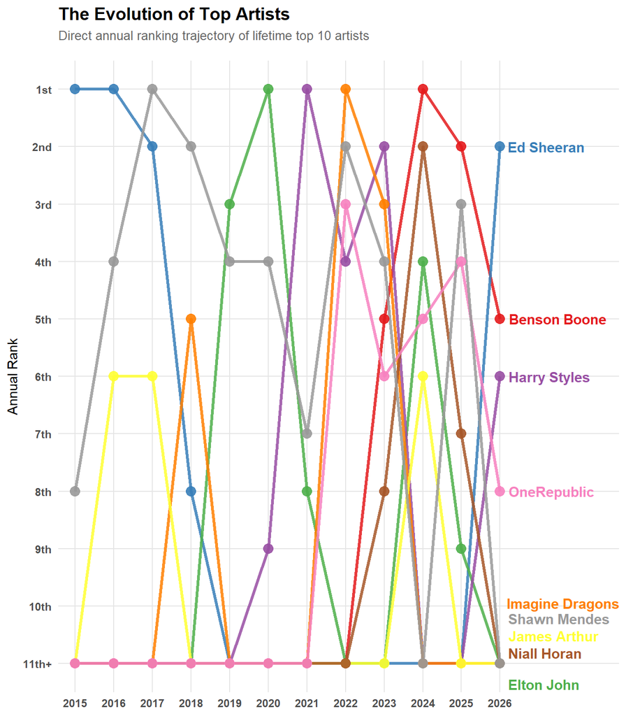

```r
# Calculate total hours for every artist ever listened to, by year
all_artists_annual <- streaming_data |>
  filter(!is.na(master_metadata_album_artist_name),
         master_metadata_album_artist_name != "",
         master_metadata_album_artist_name != "Unknown") |>
  group_by(year, master_metadata_album_artist_name) |>
  summarise(total_hours = sum(ms_played) / 3600000, .groups = "drop")

# Rank every single artist globally per year against the entire library
all_artists_ranked <- all_artists_annual |>
  group_by(year) |>
  mutate(true_rank = row_number(desc(total_hours))) |>
  ungroup()

# Identify overall Top 5 Lifetime top artists (by hour)
top_5_lifetime <- all_artists_annual |>
  group_by(master_metadata_album_artist_name) |>
  summarise(lifetime_hours = sum(total_hours), .groups = "drop") |>
  slice_max(lifetime_hours, n = 10, with_ties = FALSE) |>
  pull(master_metadata_album_artist_name)

# Isolate lifetime favourites, capping the display grid view at Rank 11
artist_migration_final <- all_artists_ranked |>
  filter(master_metadata_album_artist_name %in% top_5_lifetime) |>
  complete(year, master_metadata_album_artist_name) |>
  # If artist drop below Rank 10, they anchor cleanly at 11 ("11th+") instead of vanishing
  mutate(display_rank = ifelse(is.na(true_rank) | true_rank > 10, 11, true_rank))

# Clean text placement anchors at the final available year vector
end_labels <- artist_migration_final |> filter(year == max(year))


###################################

artist_migration_final |>
  ggplot(aes(x = factor(year), y = display_rank, group = master_metadata_album_artist_name, colour = master_metadata_album_artist_name)) +

  # Lines and Points
  geom_line(size = 1.2, alpha = 0.85) +
  geom_point(size = 3.5, alpha = 0.9) +

  # Reverse scale displaying 1st through 10th with an 11th+ cushion row
  scale_y_reverse(
    breaks = 1:11,
    labels = c("1st", "2nd", "3rd", "4th", "5th", "6th", "7th", "8th", "9th", "10th", "11th+")
  ) +

  # High-visibility professional light palette
  scale_colour_brewer(palette = "Set1") +

  # Inline typography labels at the right edge margin
  geom_text_repel(
    data = end_labels,
    aes(label = master_metadata_album_artist_name),
    hjust = 0,
    nudge_x = 0.15,
    direction = "y",    # only adjust vertically
    box.padding = 0.15,
    point.padding = 0.1,
    segment.color = NA,
    fontface = "bold",
    size = 4
  ) +

  labs(
    title = "The Evolution of Top Artists",
    subtitle = "Direct annual ranking trajectory of lifetime top 10 artists",
    x = NULL, y = "Annual Rank"
  ) +

  # Extra margin padding on the right side prevents artist names from getting clipped
  scale_x_discrete(expand = expansion(mult = c(0.04, 0.28))) +

  # Polished Light Theme Design
  theme_minimal() +
  theme(
    legend.position = "none",
    panel.grid.minor = element_blank(),
    panel.grid.major.y = element_line(colour = "gray90", size = 0.5),
    panel.grid.major.x = element_line(colour = "gray90", size = 0.5),

    # Text Hierarchies
    plot.title = element_text(face = "bold", size = 14),
    plot.subtitle = element_text(size = 10, colour = "gray40", margin = margin(b = 15)),
    axis.text.x = element_text(face = "bold"),
    axis.text.y = element_text(face = "bold")
  )
```

To address the first question of interest in a slightly different way, I looked to create a profile plot for each of artist in my top 10. However, upon creating this profile plot, it is … a mess, like a toddler took to the brand new white walls of the house with a packet of crayons.  
The encoding of each artist to a line, and point showing its position in my top 10 (or outside of it, in the 11+ category), as well as encoding by colour, and severe over plotting, particularly in the 11+ category, shows that some plots reach capacity very quickly. This was a much better version of some of the earlier iterations of this plot, but still is an overall pretty horrid plot. To show how this can be improved, I incorporated a range of more effective data visualisation techniques to improve this, to see how the behaviour of my top 10 artists over time behaved.

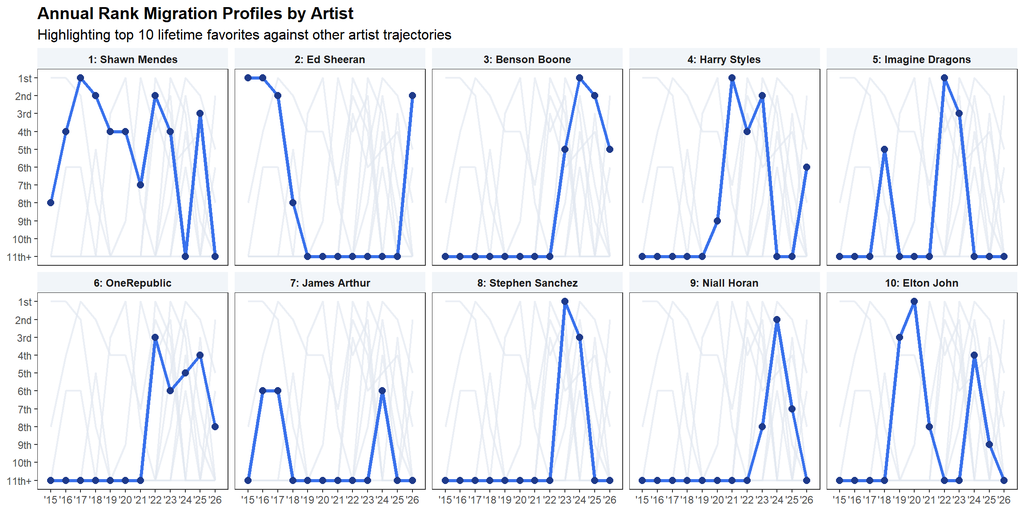

```r
# Additional data manipulation

# First, figure out the top 10 lifetime artists and their ranks
top_10_lifetime_df <- all_artists_annual |>
  group_by(master_metadata_album_artist_name) |>
  summarise(metric = sum(total_hours), .groups = "drop") |>
  slice_max(metric, n = 10, with_ties = FALSE) |>
  arrange(desc(metric)) |>
  # Create the numbered labels (e.g., "1: Artist Name")
  mutate(rank_num = row_number(),
         numbered_artist = paste0(rank_num, ": ", master_metadata_album_artist_name))

# Create a clean lookup vector to match names to their new numbered labels
artist_labels <- top_10_lifetime_df$numbered_artist
names(artist_labels) <- top_10_lifetime_df$master_metadata_album_artist_name

# Filter, complete, and transform your main dataset with the new numbered factor
artist_migration_final <- all_artists_ranked |>
  filter(master_metadata_album_artist_name %in% names(artist_labels)) |>
  complete(year, master_metadata_album_artist_name) |>
  mutate(
    display_rank = ifelse(is.na(true_rank) | true_rank > 10, 11, true_rank),
    # Replace raw names with numbered strings and explicitly lock in the order
    master_metadata_album_artist_name = artist_labels[master_metadata_album_artist_name],
    master_metadata_album_artist_name = factor(master_metadata_album_artist_name, levels = artist_labels)
  )

# Now build the background shadow dataset using the newly formatted factor column
background_shadow <- artist_migration_final |>
  select(year, display_rank, shadow_artist = master_metadata_album_artist_name)


# ==========================================
# Plot
artist_migration_final |>
  ggplot(aes(x = factor(year), y = display_rank)) +

  # The entire Top 10 group mapped as background pale lines
  geom_line(data = background_shadow,
            aes(group = shadow_artist, x = factor(year)),
            colour = "#E2E8F0", size = 0.8, alpha = 0.7) +

  # The specific highlighted artist lane unique to each individual facet
  geom_line(aes(group = master_metadata_album_artist_name),
            colour = "#2563EB", size = 1.3, alpha = 0.9) +
  geom_point(aes(group = master_metadata_album_artist_name),
             colour = "#1E3A8A", size = 2.5) +

  # Y Label Rank
  scale_y_reverse(
    breaks = 1:11,
    labels = c("1st", "2nd", "3rd", "4th", "5th", "6th", "7th", "8th", "9th", "10th", "11th+")
  ) +

  scale_x_discrete(
    labels = function(x) {
      paste0("'", substr(as.character(x), 3, 4))
    },
    expand = expansion(mult = c(0.08, 0.08))
  ) +

  # Split by artist
  facet_wrap(~master_metadata_album_artist_name, ncol = 5) +

  labs(
    title = "Annual Rank Migration Profiles by Artist",
    subtitle = "Highlighting top 10 lifetime favorites against other artist trajectories",
    x = NULL, y = NULL
  ) +

  theme_bw() +
  theme(
    panel.grid = element_blank(),

    # Header card typography and formatting
    strip.text = element_text(face = "bold", size = 9),
    strip.background = element_rect(fill = "#F1F5F9", colour = NA),

    plot.title = element_text(face = "bold", size = 14),
    plot.subtitle = element_text(size = 12)
  )
```

Comparing to the previous iteration of this plot in the collapsed section above, we now see a much more orderly and interpretable plot. By faceting each of the artists, and ordering these by their top 10 position, allows us to see better, both the trends over time for each artist, but how this compares over time within each artist as well.

As discussed earlier, when faceting, the same relative positioning is lost (through unaligned vertical and horizontal positions), as each facet has a different location on the plot. To help combat this, I previously used colour to highlight peak listening times. However, for this plot, to showcase something different, I utilise all 10 artists trajectories, but in a neutral background grey. This allows a comparison of the general trends of all top 10 artists, with the artist of interest for each particular facet. This draws on the concepts of multiple encodings for data - reusing position, by encoding each artist as a position in space in the visualisation, as well as the intra-facet encodings of position for the artists position in my top 10 ranking.

This plot is a direct improvement of the previous profile plot as we now can much easier see how the 10 artists are spaced in my top 10 list, both by order, based on position, and by ranking changing over time, from the line/point encodings. Interestingly, a number of the artists in my top 10 have low/no rankings in the earlier years, and steep peaks in later years. I can attribute this mostly to a intense period of listening for specific artists, usually aligned around the time that I saw the artist live in concert. Of these 10 artists, I have seen six of them live (at about the point they peak as well), with tickets to two others (that ultimately got cancelled/scheduling conflicts). This shows that for the top 10 artists, there is a concentration of listening around the time of when I see them live in concert - each of which likely influence each other. If I know I am seeing them live in concert, I listen to their music more, but if I listen to their music more, I am more likely to want to see them live in concert if they are in New Zealand.

I additionally use clearer text labels, relating to the use of text encoding, to show the artists position in my top 10, with the main facet labels, as well as cleaning up x-axis label text for easier readability, without compromising accuracy or interpretability.

**Click to show Iteration 1 of the next plot**

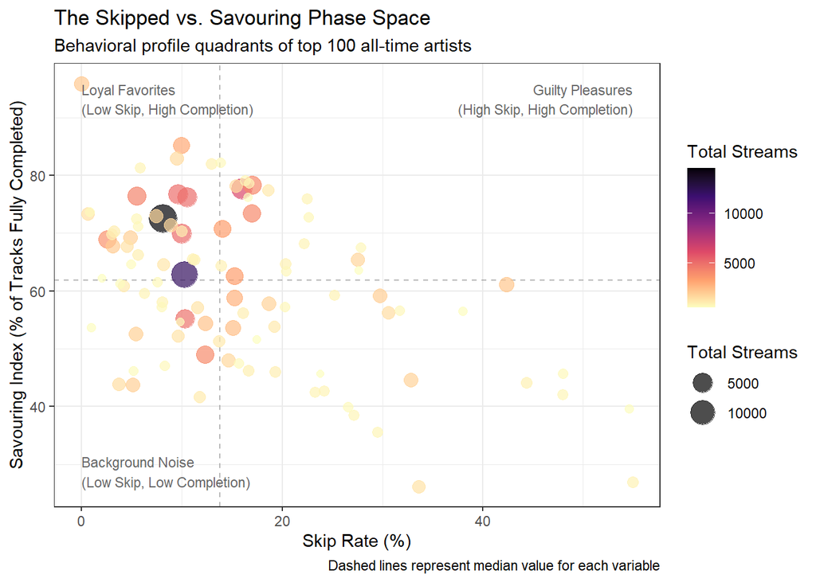

```r
# Compute behavioral metrics for your top artists
phase_space_df <- streaming_data |>
  filter(!is.na(master_metadata_album_artist_name)) |>
  group_by(master_metadata_album_artist_name) |>
  summarise(
    total_streams = n(),
    skip_rate = mean(skipped == TRUE, na.rm = TRUE) * 100,
    savoring_index = mean(reason_end == "trackdone", na.rm = TRUE) * 100,
    .groups = "drop"
  ) |>
  # Filter top 100 artists
  slice_max(total_streams, n = 100)

# Generate the base scatter plot
phase_space_df |>
  ggplot(aes(x = skip_rate, y = savoring_index)) +
    # Cross hairs representing your median behavioural baseline across your top artists
    geom_vline(xintercept = median(phase_space_df$skip_rate), linetype = "dashed", color = "grey60", alpha = 0.7) +
    geom_hline(yintercept = median(phase_space_df$savoring_index), linetype = "dashed", color = "grey60", alpha = 0.7) +
    # Map point size and colour density to total streaming volume
    geom_point(aes(size = total_streams, color = total_streams), alpha = 0.7) +
    scale_color_viridis_c(option = "magma", direction = -1, name = "Total Streams") +
    scale_size_continuous(name = "Total Streams", range = c(2, 8)) +
    # Quad-mapping annotations
    annotate("text", x = min(phase_space_df$skip_rate), y = max(phase_space_df$savoring_index),
             label = "Loyal Favorites\n(Low Skip, High Completion)", hjust = 0, vjust = 1, color = "grey40", size = 3) +
    annotate("text", x = max(phase_space_df$skip_rate), y = max(phase_space_df$savoring_index),
             label = "Guilty Pleasures\n(High Skip, High Completion)", hjust = 1, vjust = 1, color = "grey40", size = 3) +
    annotate("text", x = min(phase_space_df$skip_rate), y = min(phase_space_df$savoring_index),
             label = "Background Noise\n(Low Skip, Low Completion)", hjust = 0, vjust = 0, color = "grey40", size = 3) +
    theme_bw() +
    labs(
      title = "The Skipped vs. Savouring Phase Space",
      subtitle = "Behavioral profile quadrants of top 100 all-time artists",
      x = "Skip Rate (%)",
      y = "Savouring Index (% of Tracks Fully Completed)",
      caption = "Dashed lines represent median value for each variable"
    ) +
    theme(legend.position = "right")
```

This plot uses multiple encodings to present some new variables (further described below), but the gripe I have with this version of it, is the ambiguity of the legend and duplication of the legend sections. Yes, there are multiple encodings that generate different legends, however, I feel that this could be portrayed in a better and more intuitive method. This is what the next iteration of the plot aims to fix - retaining the plot window as is, and fixing the legend.

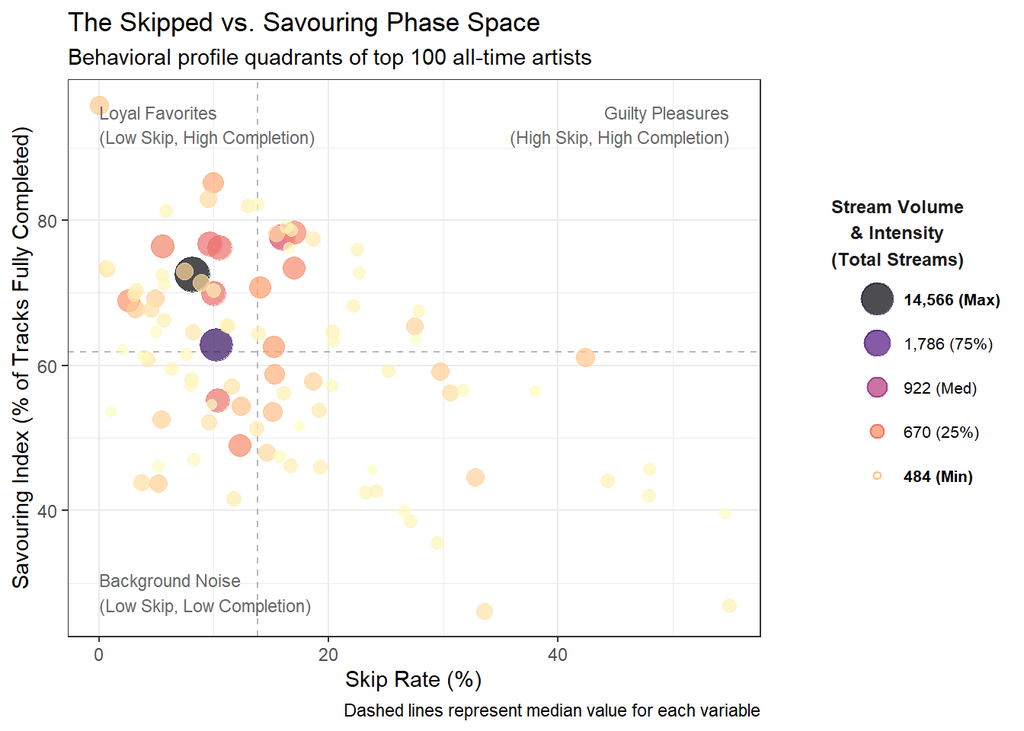

```r
benchmarks <- quantile(phase_space_df$total_streams, probs = c(0, 0.25, 0.5, 0.75, 1))

p_min  <- round(benchmarks[1]) # Lightest / Smallest
p_q1   <- round(benchmarks[2])
p_med  <- round(benchmarks[3])
p_q3   <- round(benchmarks[4])
p_max  <- round(benchmarks[5]) # Darkest / Largest

# Quartile Splits for legend
sizes  <- c(2.0, 3.5, 5.0, 6.5, 8.0)                               # Absolute radii sizes
colors <- c("#FCFDBFFF", "#FB8861FF", "#B63679FF", "#51127CFF", "#000004FF") # Light to Dark

y_pos <- c(0.18, 0.32, 0.46, 0.60, 0.74)  # Min to Max, bottom to top
cx <- 0.4 # Circle centre x

hybrid_legend_grob5 <- grobTree(
  # Title
  textGrob("Stream Volume\n& Intensity\n(Total Streams)", x = 0.5, y = 0.95,
           gp = gpar(fontface = "bold", fontsize = 9, col = "grey10")),

  # Circles (individual, stacked)
  circleGrob(x = unit(cx, "npc"), y = unit(y_pos[1], "npc"), r = unit(sizes[1], "pt"),
             gp = gpar(fill = colors[1], col = "#FE9F6D",  alpha = 0.7)),  # Min
  circleGrob(x = unit(cx, "npc"), y = unit(y_pos[2], "npc"), r = unit(sizes[2], "pt"),
             gp = gpar(fill = colors[2], col = "#E65C40",  alpha = 0.7)),  # 25%
  circleGrob(x = unit(cx, "npc"), y = unit(y_pos[3], "npc"), r = unit(sizes[3], "pt"),
             gp = gpar(fill = colors[3], col = "#8C2981",  alpha = 0.7)),  # Med
  circleGrob(x = unit(cx, "npc"), y = unit(y_pos[4], "npc"), r = unit(sizes[4], "pt"),
             gp = gpar(fill = colors[4], col = "#3B0F70",  alpha = 0.7)),  # 75%
  circleGrob(x = unit(cx, "npc"), y = unit(y_pos[5], "npc"), r = unit(sizes[5], "pt"),
             gp = gpar(fill = colors[5], col = "#1b1432",  alpha = 0.7)),  # Max

  # Labels
  textGrob(paste0(scales::comma(p_max), " (Max)"), x = 0.53, y = y_pos[5], hjust = 0,
           gp = gpar(fontsize = 8, fontface = "bold")),
  textGrob(paste0(scales::comma(p_q3),  " (75%)"), x = 0.53, y = y_pos[4], hjust = 0,
           gp = gpar(fontsize = 8)),
  textGrob(paste0(scales::comma(p_med), " (Med)"), x = 0.53, y = y_pos[3], hjust = 0,
           gp = gpar(fontsize = 8)),
  textGrob(paste0(scales::comma(p_q1),  " (25%)"), x = 0.53, y = y_pos[2], hjust = 0,
           gp = gpar(fontsize = 8)),
  textGrob(paste0(scales::comma(p_min), " (Min)"), x = 0.53, y = y_pos[1], hjust = 0,
           gp = gpar(fontsize = 8, fontface = "bold"))
)

##################################
# Plot

phase_space_df |>
  ggplot(aes(x = skip_rate, y = savoring_index)) +
    geom_vline(xintercept = median(phase_space_df$skip_rate), linetype = "dashed", color = "grey60", alpha = 0.7) +
    geom_hline(yintercept = median(phase_space_df$savoring_index), linetype = "dashed", color = "grey60", alpha = 0.7) +

    geom_point(aes(size = total_streams, color = total_streams), alpha = 0.7) +
    scale_color_viridis_c(option = "magma", direction = -1, name = "Total Streams") +
    scale_size_continuous(range = c(2, 8)) +

    # Anotations
    annotate("text", x = min(phase_space_df$skip_rate), y = max(phase_space_df$savoring_index),
             label = "Loyal Favorites\n(Low Skip, High Completion)", hjust = 0, vjust = 1, color = "grey40", size = 3) +
    annotate("text", x = max(phase_space_df$skip_rate), y = max(phase_space_df$savoring_index),
             label = "Guilty Pleasures\n(High Skip, High Completion)", hjust = 1, vjust = 1, color = "grey40", size = 3) +
    annotate("text", x = min(phase_space_df$skip_rate), y = min(phase_space_df$savoring_index),
             label = "Background Noise\n(Low Skip, Low Completion)", hjust = 0, vjust = 0, color = "grey40", size = 3) +
    theme_bw() +
    labs(
      title = "The Skipped vs. Savouring Phase Space",
      subtitle = "Behavioral profile quadrants of top 100 all-time artists",
      x = "Skip Rate (%)",
      y = "Savouring Index (% of Tracks Fully Completed)",
      caption = "Dashed lines represent median value for each variable"
    ) +
    guides(
      color = "none",
      size  = "none",
      custom = guide_custom(
        grob   = hybrid_legend_grob5,
        width  = unit(3.6, "cm"),
        height = unit(5.5, "cm"),
        title  = "")
    ) +
    theme(
      legend.position = "right"
    )
```

To pivot to some different variables in this extremely rich data set, I now explore some other uses of multiple encodings and data summaries, but now with variables relating to skipped songs, and duration played for individual tracks. I created a summary variable that had the proportion of songs that were skipped for that artist, as well as the proportion of songs that were played to the end naturally for that artist. This allows me to understand the trends in if I am a serial skipper, or allow songs to play through to the end.

To help highlight differences, I have added additional dashed lines to the plot which show the median skip rate and median savouring index. It can be seen that the larger circles (artists who have more streams) tend to be above the median in terms of more complete listens, and fewer skips (the top left quadrant). Artists with fewer overall streams (smaller yellow points) tend to be skipped more often, but there are still artists that have fewer streams that are skipped as often as the largest stream volume artists.

Although size/area is not as strong of an encoding for accuracy (like position), utilising the colour scale helps add some additional security into the plot to allow for a more accurate decoding. Whilst a completely accurate decoding is not possible, this second iteration of the plot produces a much better version, given it is a more customised legend. It is also possible to visually see groupings and patterns without the legend anyway, and this just supports additional interpretation

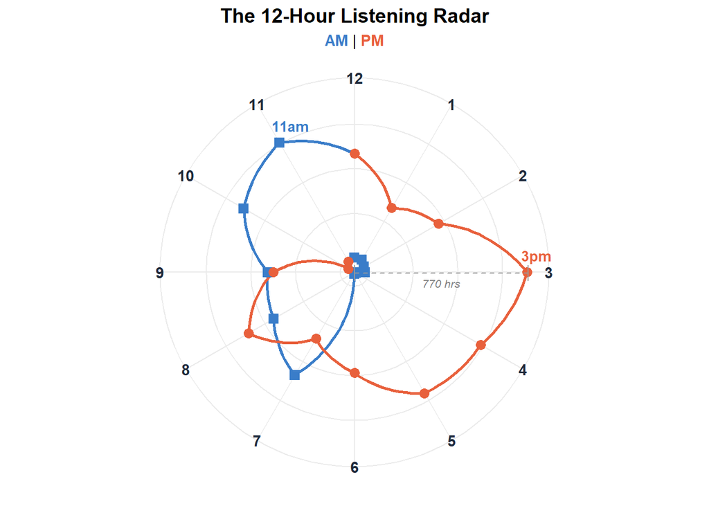

```r
# AM runs 0-11, close at 12 noon
# PM runs 0-11, close at 12 midnight
radar_raw <- streaming_data |>
  mutate(
    hour_12 = hour %% 12,
    time_of_day = ifelse(hour < 12, "AM", "PM")
  ) |>
  group_by(hour_12, time_of_day) |>
  summarise(total_ms = sum(ms_played), .groups = "drop") |>
  complete(hour_12 = 0:11, time_of_day, fill = list(total_ms = 0))

am_data <- radar_raw |> filter(time_of_day == "AM") |> arrange(hour_12)
pm_data <- radar_raw |> filter(time_of_day == "PM") |> arrange(hour_12)

radar_plot_data <- bind_rows(
  # AM loop: hours 0-11, closes with PM's hour 0 (noon)
  am_data |>
    bind_rows(pm_data |> slice(1) |> mutate(time_of_day = "AM", hour_12 = 12)),

  # PM loop: hours 0-11, closes with AM's hour 0 (midnight)
  pm_data |>
    bind_rows(am_data |> slice(1) |> mutate(time_of_day = "PM", hour_12 = 12))
)

#################
# Plot

radar_plot <- radar_plot_data |>
  ggplot(aes(x = hour_12, y = total_ms,
             colour = time_of_day, group = time_of_day)) +

  #Path for the points
  geom_path(linewidth = 1) +

  geom_point(
    data = radar_plot_data |> filter(hour_12 < 12),
    aes(shape = time_of_day), size = 3
  ) +

  #Label Peak for each loop
  geom_text(
  data = radar_plot_data |>
    filter(hour_12 < 12) |>
    group_by(time_of_day) |>
    slice_max(total_ms, n = 1),
  aes(label = paste0(ifelse(hour_12 == 0, "12", hour_12), ifelse(time_of_day == "AM", "am", "pm"))),
  size = 3.5,
  fontface = "bold",
  vjust = -1,
  hjust = 0.2
  ) +

  coord_polar(start = 0, direction = 1) +

  ## Set Clock like labels
  scale_x_continuous(
    breaks = 0:11,
    labels = c("12", "1", "2", "3", "4", "5", "6", "7", "8", "9", "10", "11")
  ) +

  scale_colour_manual(values = c("AM" = "#3A7DC9", "PM" = "#E8603C"), guide = "none") +
  scale_shape_manual(values = c("AM" = 15, "PM" = 16), guide = "none") +

  labs(
  title = "The 12-Hour Listening Radar",
  subtitle = "<span style='color:#3A7DC9'>**AM**</span> | <span style='color:#E8603C'>**PM**</span>",
  x = NULL, y = NULL
  ) +

  # Theme adjustments
  theme_minimal() +
  theme(
    legend.position = "bottom",
    axis.text.y = element_blank(),
    panel.grid.major.y = element_line(colour = "gray92", linewidth = 0.5),
    panel.grid.major.x = element_line(colour = "gray92", linewidth = 0.5),
    panel.grid.minor = element_blank(),
    axis.text.x = element_text(face = "bold", colour = "#1E293B", size = 11),
    plot.title = element_text(face = "bold", hjust = 0.5, size = 14),
    plot.subtitle = element_markdown(hjust = 0.5),
  )


################
# Grid Additions

print(radar_plot)

max_ring  <- max(radar_plot_data$total_ms, na.rm = TRUE)
hrs       <- signif(max_ring / (1000 * 60 * 60), 2)

# Horizontal scale bar at 3 o'clock position
center_x  <- 0.50
outer_x   <- 0.745  # right edge at 3 o'clock
mid_x     <- (center_x + outer_x) / 2
bar_y     <- 0.46  # vertical position of the 3 o'clock axis

# Horizontal scale bar line
grid.lines(
  x = unit(c(center_x, outer_x), "npc"),
  y = unit(c(bar_y, bar_y), "npc"),
  gp = gpar(col = "grey60", lwd = 1, lty = "dashed")
)

# Left tick (center)
grid.lines(
  x = unit(c(center_x, center_x), "npc"),
  y = unit(c(bar_y - 0.015, bar_y + 0.015), "npc"),
  gp = gpar(col = "grey60", lwd = 1)
)

# Right tick (outer ring / max point)
grid.lines(
  x = unit(c(outer_x, outer_x), "npc"),
  y = unit(c(bar_y - 0.015, bar_y + 0.015), "npc"),
  gp = gpar(col = "grey60", lwd = 1)
)

# Label below the midpoint so it doesn't clash with the PM line
grid.text(
  label = paste0(hrs, " hrs"),
  x = unit(mid_x, "npc"),
  y = unit(bar_y - 0.02, "npc"),
  gp = gpar(col = "grey50", fontsize = 8, fontface = "italic")
)
```

Another cool plot that I have seen in the past, when dealing with time covariates, are radar plots. These often encode the data to be a circle with the 24 hours of time all in one loop. However, to me, reading a radar plot with 24hours in one circle is not intuitive. As humans, when we look at a circle and have associated time, we think of clocks. However, with a clock, this is obviously only split into 12 hour sections. One way around this, is to have two overlaid series in a radar plot, showing both morning and afternoon. However, when filled in, these create plots that are quite difficult to interpret.

To answer question 3, regarding peak listening times, I wanted to try a two loop radar plot, with no fill. This would create two loops one for each half of the day. With some careful data manipulation, I have the two loops coloured differently, encoding time of day to colour, as well as shape. The value of the number of hours listened at a particular time of day is the distance/position in space, from the centre. This allows me to see that my two main peaks of time are at 11am and 3pm, with 3pm being the largest number of hours listened at 770 hours across the entire data set.

Whilst a little unconventional, this plot somewhat makes use of the idea of visual objects. The clock face is a learned visual object that most humans are familiar with. By encoding the data to be two loops and have 12 hours in the radar, not 24, we can associate the plot more with the idea of time and a clock face for the time of day. Utilising differences in the encoding of shapes, colour as well as a customised colour subtitle, helps map the time of day accurately to be either the blue or orange loops. Finally, utilising `grid` again, we are able to add a custom annotation to the plot that serves as a scaling metric (almost like a legend), to give sense to the scale of the points and what they represent.

This type of visualisation does take a little bit of time to interpret, as its not as conventional as usual, but once understood, it can be quite visually appealing seeing how the ups and downs on the loop are associated with the times, as aligned with a clock visual object.

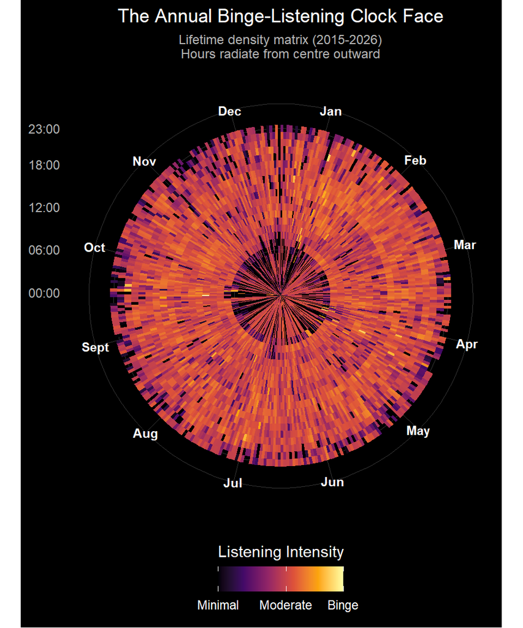

```r
calendar_wheel_df <- streaming_data |>
  # Filter out missing records if any exist
  filter(!is.na(time)) |>
  mutate(
    # Day of the Year
    Day_of_Year = as.integer(format(time, "%j")),
    Hour = as.integer(hour)
  ) |>
  # Aggregate listening minutes across history
  group_by(Day_of_Year, Hour) |>
  summarise(
    total_minutes = sum(ms_played, na.rm = TRUE) / 60000,
    .groups = "drop"
  ) |>
  # Apply log1p transformation to balance the scale across 277k rows of variance
  mutate(log_minutes = log1p(total_minutes))


# Manipulation for month label positioning
month_breaks <- data.frame(date = seq(as.Date("2024-01-01"), as.Date("2024-12-31"), by = "month")) |>
  mutate(
    Month_Label = format(date, "%b"),
    Start_Day = as.integer(format(date, "%j")),
    End_Day = as.integer(format(seq(as.Date("2024-02-01"), as.Date("2025-01-01"), by = "month") - 1, "%j"))
  ) |>
  mutate(Mid_Day = (Start_Day + End_Day) / 2)

# Plot
ggplot(calendar_wheel_df, aes(x = Day_of_Year, y = Hour, fill = log_minutes)) +
  geom_tile(color = NA, width = 1, height = 1) +
  # Project into a continuous polar dial, locking 00:00 to the top centre
  coord_polar(theta = "x", start = 0, direction = 1) +
  # High contrast scale + 3x labels
  scale_fill_viridis_c(
    option = "inferno",
    name = "Listening Intensity",
    labels = c("Minimal", "Moderate", "Binge"),
    breaks = c(
      min(calendar_wheel_df$log_minutes[calendar_wheel_df$log_minutes > 0]),
      median(calendar_wheel_df$log_minutes[calendar_wheel_df$log_minutes > 0]),
      max(calendar_wheel_df$log_minutes)
    )
  ) +
  # Map labels using our computed seasonal midpoints
  scale_x_continuous(breaks = month_breaks$Mid_Day, labels = month_breaks$Month_Label, expand = c(0, 0)) +
  scale_y_continuous(breaks = c(0, 6, 12, 18, 23), labels = c("00:00", "06:00", "12:00", "18:00", "23:00")) +
  theme_minimal() +
  labs(
    title = "The Annual Binge-Listening Clock Face",
    subtitle = "Lifetime density matrix (2015-2026)\nHours radiate from centre outward",
    x = NULL,
    y = NULL
  ) +
  theme(
    # Dark Background
    plot.background = element_rect(fill = "black", color = NA),
    panel.background = element_rect(fill = "black", color = NA),
    plot.title = element_text(color = "white", hjust = 0.5),
    plot.subtitle = element_text(color = "grey70", size = 9, hjust = 0.5, margin = margin(b = 15)),
    # External seasonal rings text styling
    axis.text.x = element_text(color = "white", face = "bold"),
    # Internal cross-cutting hour track text styling
    axis.text.y = element_text(color = "grey70"),
    panel.grid.major = element_line(color = "grey20", linewidth = 0.25),
    panel.grid.minor = element_blank(),
    legend.position = "bottom",
    legend.text = element_text(color = "white"),
    legend.title.position = "top",
    legend.title = element_text(color = "white")
  )
```

To mitigate for large variation in some listening hours, I did use a log transformation, such that extreme outliers (like those seen in earlier box plots), do not completely overwhelm the scales. Through the use of an adjusted legend, I have converted what would be a meaningless and difficult log scale legend, into a human understandable scale. Although a more holistic than quantitative visualisation, it is still interesting to see the patterns that this plot has created. From the darker centre, where less music listening occurs overnight, as well as small divots and bumps at the outermost values (also from overnight listening), to the implicit visual shapes that are created through rings in the data. This shows the consistency in the distribution of the listening habits across many months, for the 11 years of data.

Utilising the `inferno` scale from the viridis series, log listening intensity is encoded as colour, all time variables (hour, day and month), are encoded as position, on a polar coordinate. Again text additions are used to further support the visualisation, through subtitles, and labels clearly indicating what the plot dictates.

Although not explicitly an amazing plot, as it is only useful for general pattern searching, not accurate extraction of raw data values, I just think it looks like a cool plot - almost like an eye, but perhaps that of a sentient being, not a human!

# Summary

Through this series of visualisations with my own Spotify listening data, I have encountered some interesting trends and features of my own music taste and listening history. By utilising different combinations of these varaibles, I have created a series of visual appealing, and informative plots utilising key data visualisation concepts. These include

- Appropriate encodings for qualitative and quantitative variables
- Visual Features, Shapes and Objects
- Encoding data summaries
- Encoding text
- Multiple encodings
- Implicit Visual Features
- The Human Visual System
- Colour and its capacity, with strengths and weaknesses
- A variety of packages including `ggplot2` (and its extensions), `grid` (and its extensions) and `patchwork`

and many data visualisation and data science concepts!